# Morti sul luogo di lavoro (USA, 2014 - 2020)

27/09/2023

## Database pubblici

Le morti sul luogo di lavoro sono sempre state, e rimarranno, un problema comune e purtroppo tutt’ora sottovalutato, visti anche i casi ultimamente verificati (anche durante l’alternanza scuola-lavoro).

Scopo:

- Informativo
- Sensibilizzazione

Essendoci una quantità enorme di variabili da analizzare, lo studio in questione si limiterà a fornire dati per puro scopo informativo e non mira a scoprire le cause principali.

## Dataset

Perchè gli USA?

- Grandi quantità di dati
- Dati aperti al pubblico

Verranno utilizzati molti meno dati di quelli forniti (es. città, causa, stato, occupazione ecc… non vengono usati)

Non tutti i dati erano standardizzati sotto lo stesso formato.

Source: https://www.coshnetwork.org/fatality-database

## Organizzazione dei dati

Dati 6 anni da analizzare, è importante cominciare ad organizzare i dati per poterli usare al meglio.

Organizzazione per:

- Genere (male, female, NA)
- Età (fasce di età)
- Mese

## Distinzione di genere

C’è una distinzione di genere? si organizzano i dati in maniera appropriata per scoprirlo.

*Riferimenti alla media annuale dal 2014 al 2020*

```
##   gender count
## 1 female   138
## 2   male  1041
## 3     NA   285
```

## Distinzione di genere

*Riferimenti alla media annuale dal 2014 al 2020*

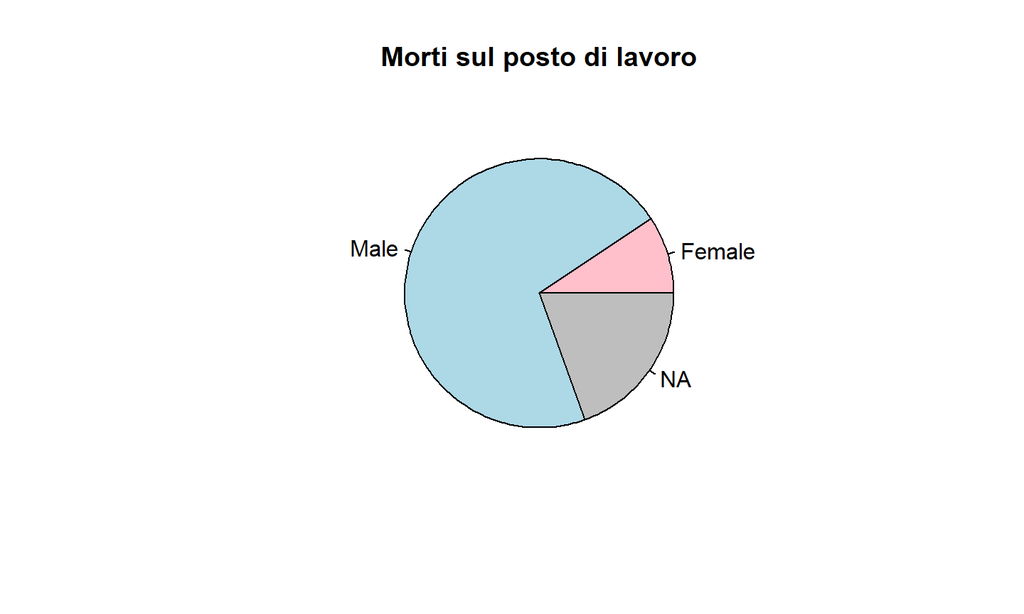

```
## [1] Inf
```

C’è una netta distinzione, il genere maschile rientra nel 71% delle vittime.

## Distinzione di genere

Stando ai dati riportati dal Bureau of Labor Statistics (BLS), ossia il dipartimento del lavoro Statunitense, il genere maschile è più propenso a fare lavori manuali come l’elettricista, il meccanico ecc…

La forza lavoro maschile è pari al 96%-98%.

Questo è sicuramente un fattore da tenere in considerazione in quanto, facendo lavori manuali, ci sono più probabilità di commettere incidenti mortali.

Source: https://www.zippia.com/advice/male-dominated-careers-female/

## Fasce di età

Ci sono distinzioni di età? si organizzano i dati in maniera appropriata per scoprirlo.

*Riferimenti alla media annuale dal 2014 al 2020*

```
##   ageRange count
## 1      <18     8
## 2    19-35   194
## 3    36-50   244
## 4    51-75   637
## 5      >76    17
## 6       NA   422
```

## Fasce di età

*Riferimenti alla media annuale dal 2014 al 2020*

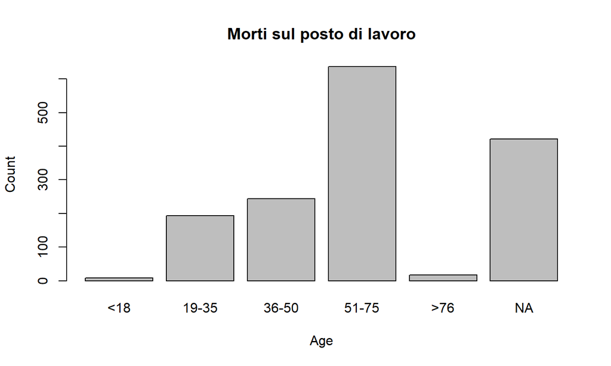

La fascia più colpita è quella dei 51-75 anni. Causa?

Logicamente, si pensa al tipo di lavoro svolto: internet ha cambiato ed evoluto il concetto di lavoro.

I giovani lavoratori possono scegliere di lavorare in ambito digitale, una volta non c’era questa possibilità o era molto più ristretta.

## Organizzazione dei mesi

C’è distinzione nel periodo dell’anno? si organizzano i dati in maniera appropriata per scoprirlo.

*Riferimenti alla media annuale dal 2014 al 2020*

```
##        month count
## 1    January   103
## 2   February    78
## 3      March    97
## 4      April   138
## 5        May   128
## 6       June   128
## 7       July   120
## 8     August   121
## 9  September   109
## 10   October    91
## 11  November    88
## 12  December    96
```

## Organizzazione dei mesi

*Riferimenti alla media annuale dal 2014 al 2020*

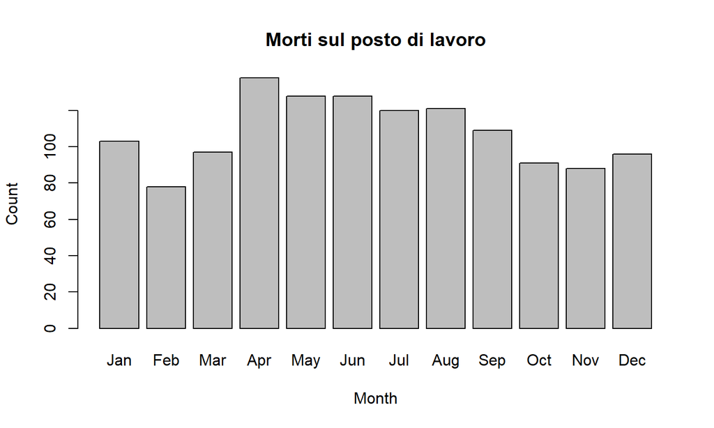

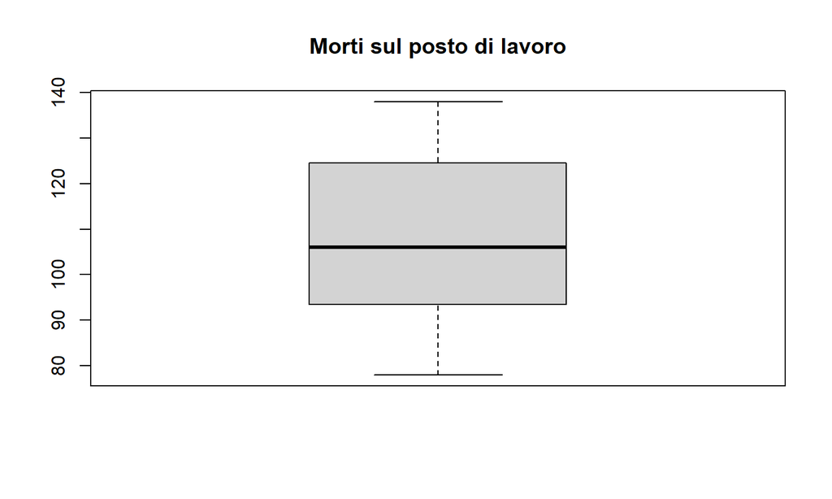

```
##    Min. 1st Qu.  Median    Mean 3rd Qu.    Max.
##   78.00   94.75  106.00  108.08  122.75  138.00
```

Il grafico è abbastanza piatto, Febbraio ha il 56% di morti di Aprile.

```
## [1] 0.5652174
```

Sono registrate in media 1300 morti all’anno.

## Conclusioni

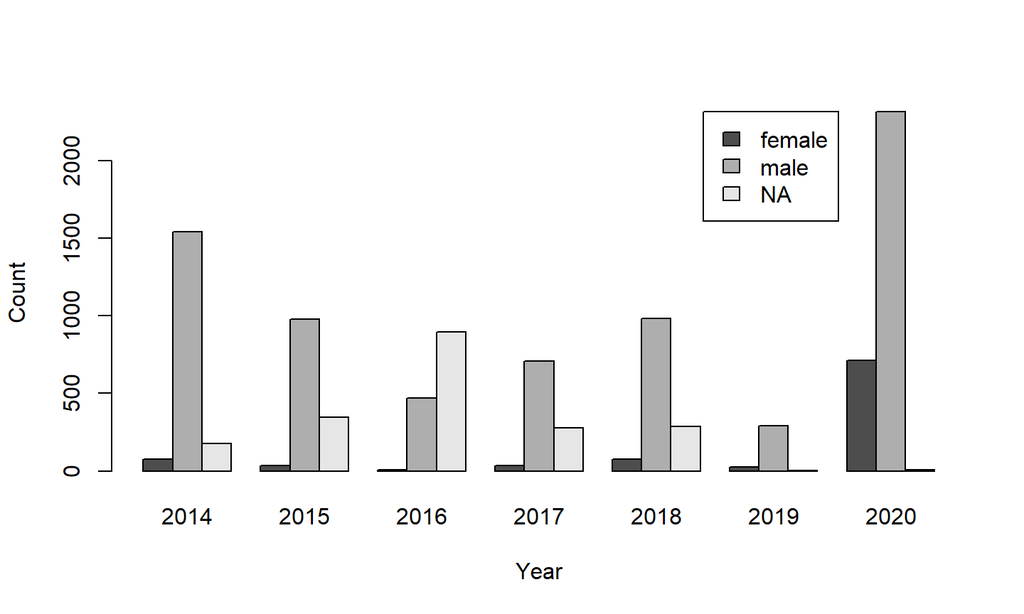

In generale si può vedere come, con l’aumentare degli anni, diminuissero le morti annuali.

I dati degli anni del 2019 e del 2020 risultano però “falsati” a causa del CoVid-19. Si può notare infatti come nel 2019 si sono registrati dei numeri molto bassi dovuti allo smart working, per poi risalire nel 2020 poichè, nel database preso in considerazione, tra le cause di morti su lavoro, sono registrati anche i casi di CoVid-19.

## Grazie mille dell’attenzione

Domande?